# Practical Machine Learning Course Project

T-StrawClown

March 30, 2016

### Summary

This document is a part of the Practical Machine Learning by JHU course on Coursera describing how a prediction model was built in order to achieve the objectives set by course project.

Six young health participants were asked to perform one set of 10 repetitions of the Unilateral Dumbbell Biceps Curl in five different fashions: exactly according to the specification (Class A), throwing the elbows to the front (Class B), lifting the dumbbell only halfway (Class C), lowering the dumbbell only halfway (Class D) and throwing the hips to the front (Class E).

Class A corresponds to the specified execution of the exercise, while the other 4 classes correspond to common mistakes. Participants were supervised by an experienced weight lifter to make sure the execution complied to the manner they were supposed to simulate. The exercises were performed by six male participants aged between 20-28 years, with little weight lifting experience. Read more: http://groupware.les.inf.puc-rio.br/har#ixzz44SkACKS3

The goal of this project is use data from accelerometers on the belt, forearm, arm, and dumbell of 6 participants to build machine learning algorithm and apply it to the 20 test cases available in the test data, predicting the manner in which participants did the exercise.

The training data for this project are available here: https://d396qusza40orc.cloudfront.net/predmachlearn/pml-training.csv

The test data are available here: https://d396qusza40orc.cloudfront.net/predmachlearn/pml-testing.csv

### Modelling Approach

Considering available computing capacity, the size and complexity of training data set I chose to:  
* use only variables that are available in testing set, excluding those not containing any values (completely empty columns) and variables unrelated to measurements (such as timestamps)  
* split the training data into training and validation dataset  
* pre-process data using Pricipal Compomnents Analysis in order to reduce number of variables retaining 95% of variance explained  
* train 3 predictors on the training set  
* combine them together and train the ultimate prediction model on the validation set

### Data Preparation

Removing first 7 variables and variables that have no values in test data I get the following list of variables, which are going to be used for model training and predictions:

```
##  [1] "classe"               "roll_belt"            "pitch_belt"
##  [4] "yaw_belt"             "total_accel_belt"     "gyros_belt_x"
##  [7] "gyros_belt_y"         "gyros_belt_z"         "accel_belt_x"
## [10] "accel_belt_y"         "accel_belt_z"         "magnet_belt_x"
## [13] "magnet_belt_y"        "magnet_belt_z"        "roll_arm"
## [16] "pitch_arm"            "yaw_arm"              "total_accel_arm"
## [19] "gyros_arm_x"          "gyros_arm_y"          "gyros_arm_z"
## [22] "accel_arm_x"          "accel_arm_y"          "accel_arm_z"
## [25] "magnet_arm_x"         "magnet_arm_y"         "magnet_arm_z"
## [28] "roll_dumbbell"        "pitch_dumbbell"       "yaw_dumbbell"
## [31] "total_accel_dumbbell" "gyros_dumbbell_x"     "gyros_dumbbell_y"
## [34] "gyros_dumbbell_z"     "accel_dumbbell_x"     "accel_dumbbell_y"
## [37] "accel_dumbbell_z"     "magnet_dumbbell_x"    "magnet_dumbbell_y"
## [40] "magnet_dumbbell_z"    "roll_forearm"         "pitch_forearm"
## [43] "yaw_forearm"          "total_accel_forearm"  "gyros_forearm_x"
## [46] "gyros_forearm_y"      "gyros_forearm_z"      "accel_forearm_x"
## [49] "accel_forearm_y"      "accel_forearm_z"      "magnet_forearm_x"
## [52] "magnet_forearm_y"     "magnet_forearm_z"
```

Now I’ll split the training data into 2 partition - 60% of data dedicated to the *training set* (11776 cases) and 40% to the *validation set* (7846 cases).

Athough number of variables is reduced from 159 to 52, it is still a lot considering computational power that I posses, thus I have decided to do PCA on the *training set* retaining 95% or variance explained, which further reduces number of variables to 25.

```
## Created from 11776 samples and 52 variables
##
## Pre-processing:
##   - centered (52)
##   - ignored (0)
##   - principal component signal extraction (52)
##   - scaled (52)
##
## PCA needed 25 components to capture 95 percent of the variance
```

### Creating Predictors

**Random Forest**

```
## Random Forest
##
## 11776 samples
##    25 predictor
##     5 classes: 'A', 'B', 'C', 'D', 'E'
##
## No pre-processing
## Resampling: Cross-Validated (6 fold)
## Summary of sample sizes: 9813, 9812, 9813, 9813, 9815, 9814, ...
## Resampling results across tuning parameters:
##
##   mtry  Accuracy   Kappa      Accuracy SD  Kappa SD
##    2    0.9655217  0.9563770  0.003557541  0.004497659
##    4    0.9651817  0.9559475  0.005106451  0.006459521
##    8    0.9620400  0.9519812  0.004089467  0.005172578
##   16    0.9569452  0.9455407  0.004624498  0.005846239
##   25    0.9481126  0.9343641  0.006243342  0.007888332
##
## Accuracy was used to select the optimal model using  the largest value.
## The final value used for the model was mtry = 2.
```

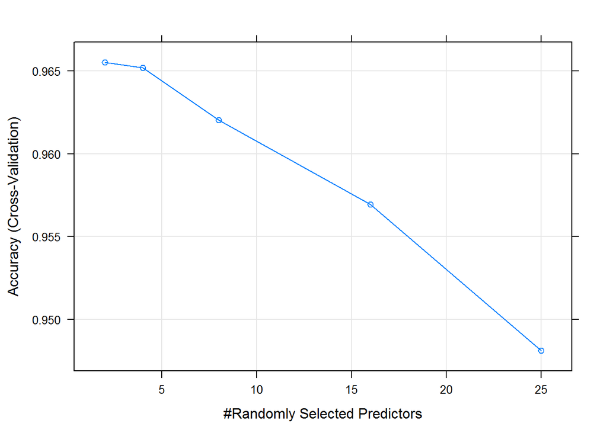

Accuracy of best perorming model (using 2 randomly selected predictor to construct tree *mtry = 2*) Random Forest applied ot the *validation set* is really good, just class D falls a bit behind.

```
## Confusion Matrix and Statistics
##
##           Reference
## Prediction    A    B    C    D    E
##          A 2216   28    0    3    1
##          B    0 1455   20    2   10
##          C   11   28 1337   70   10
##          D    4    0    8 1205    7
##          E    1    7    3    6 1414
##
## Overall Statistics
##
##                Accuracy : 0.9721
##                  95% CI : (0.9682, 0.9756)
##     No Information Rate : 0.2845
##     P-Value [Acc > NIR] : < 2.2e-16
##
##                   Kappa : 0.9647
##  Mcnemar's Test P-Value : 3.227e-16
##
## Statistics by Class:
##
##                      Class: A Class: B Class: C Class: D Class: E
## Sensitivity            0.9928   0.9585   0.9773   0.9370   0.9806
## Specificity            0.9943   0.9949   0.9816   0.9971   0.9973
## Pos Pred Value         0.9858   0.9785   0.9183   0.9845   0.9881
## Neg Pred Value         0.9971   0.9901   0.9951   0.9878   0.9956
## Prevalence             0.2845   0.1935   0.1744   0.1639   0.1838
## Detection Rate         0.2824   0.1854   0.1704   0.1536   0.1802
## Detection Prevalence   0.2865   0.1895   0.1856   0.1560   0.1824
## Balanced Accuracy      0.9936   0.9767   0.9795   0.9671   0.9890
```

**C5.0 Decision Tree**

```
## C5.0
##
## 11776 samples
##    25 predictor
##     5 classes: 'A', 'B', 'C', 'D', 'E'
##
## No pre-processing
## Resampling: Cross-Validated (6 fold)
## Summary of sample sizes: 9813, 9814, 9814, 9814, 9812, 9813, ...
## Resampling results across tuning parameters:
##
##   winnow  trials  Accuracy   Kappa      Accuracy SD  Kappa SD
##   FALSE    5      0.9053154  0.8802115  0.010871226  0.013772485
##   FALSE   10      0.9313008  0.9130712  0.006662175  0.008418856
##   FALSE   20      0.9468407  0.9327405  0.004324931  0.005469371
##    TRUE    5      0.9053154  0.8802115  0.010871226  0.013772485
##    TRUE   10      0.9313008  0.9130712  0.006662175  0.008418856
##    TRUE   20      0.9468407  0.9327405  0.004324931  0.005469371
##
## Tuning parameter 'model' was held constant at a value of tree
## Accuracy was used to select the optimal model using  the largest value.
## The final values used for the model were trials = 20, model = tree
##  and winnow = TRUE.
```

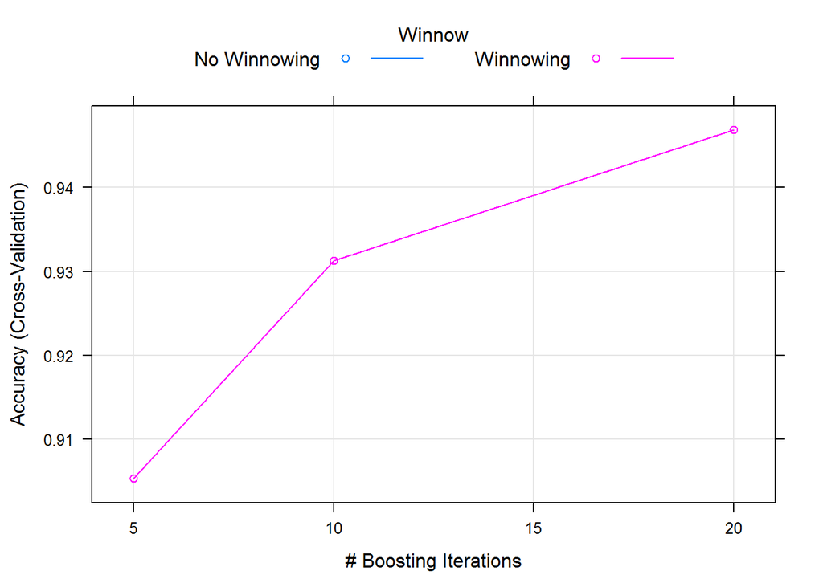

Again, good accuracy on the *validation set*.

```
## Confusion Matrix and Statistics
##
##           Reference
## Prediction    A    B    C    D    E
##          A 2189   32    6    5    3
##          B   12 1431   34    6   12
##          C   13   32 1302   62   16
##          D   11    5   17 1204    6
##          E    7   18    9    9 1405
##
## Overall Statistics
##
##                Accuracy : 0.9599
##                  95% CI : (0.9553, 0.9641)
##     No Information Rate : 0.2845
##     P-Value [Acc > NIR] : < 2.2e-16
##
##                   Kappa : 0.9492
##  Mcnemar's Test P-Value : 2.117e-06
##
## Statistics by Class:
##
##                      Class: A Class: B Class: C Class: D Class: E
## Sensitivity            0.9807   0.9427   0.9518   0.9362   0.9743
## Specificity            0.9918   0.9899   0.9810   0.9941   0.9933
## Pos Pred Value         0.9794   0.9572   0.9137   0.9686   0.9703
## Neg Pred Value         0.9923   0.9863   0.9897   0.9876   0.9942
## Prevalence             0.2845   0.1935   0.1744   0.1639   0.1838
## Detection Rate         0.2790   0.1824   0.1659   0.1535   0.1791
## Detection Prevalence   0.2849   0.1905   0.1816   0.1584   0.1846
## Balanced Accuracy      0.9863   0.9663   0.9664   0.9651   0.9838
```

**Support Vector Machine**

```
##
## Parameter tuning of 'svm':
##
## - sampling method: 10-fold cross validation
##
## - best parameters:
##  gamma cost
##    0.1   10
##
## - best performance: 0.01562445
##
## - Detailed performance results:
##   gamma cost      error  dispersion
## 1 0.001  0.1 0.63213156 0.011012195
## 2 0.010  0.1 0.37610389 0.009711619
## 3 0.100  0.1 0.15268098 0.012147496
## 4 0.001  1.0 0.43350912 0.011308407
## 5 0.010  1.0 0.18800871 0.013594308
## 6 0.100  1.0 0.04084411 0.005349402
## 7 0.001 10.0 0.35478808 0.013691968
## 8 0.010 10.0 0.08619076 0.007940292
## 9 0.100 10.0 0.01562445 0.003024109
```

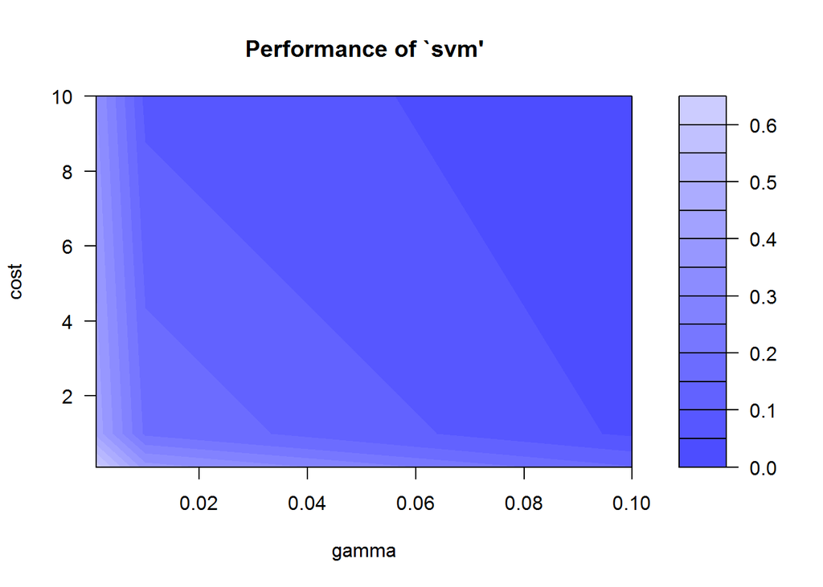

SVM produces the best accuracy of all three models on the *validation set*.

```
## Confusion Matrix and Statistics
##
##           Reference
## Prediction    A    B    C    D    E
##          A 2228   14    0    1    0
##          B    1 1489    5    0    3
##          C    1   11 1355   41    0
##          D    0    1    7 1241    3
##          E    2    3    1    3 1436
##
## Overall Statistics
##
##                Accuracy : 0.9876
##                  95% CI : (0.9849, 0.99)
##     No Information Rate : 0.2845
##     P-Value [Acc > NIR] : < 2.2e-16
##
##                   Kappa : 0.9844
##  Mcnemar's Test P-Value : 3.883e-06
##
## Statistics by Class:
##
##                      Class: A Class: B Class: C Class: D Class: E
## Sensitivity            0.9982   0.9809   0.9905   0.9650   0.9958
## Specificity            0.9973   0.9986   0.9918   0.9983   0.9986
## Pos Pred Value         0.9933   0.9940   0.9624   0.9912   0.9938
## Neg Pred Value         0.9993   0.9954   0.9980   0.9932   0.9991
## Prevalence             0.2845   0.1935   0.1744   0.1639   0.1838
## Detection Rate         0.2840   0.1898   0.1727   0.1582   0.1830
## Detection Prevalence   0.2859   0.1909   0.1795   0.1596   0.1842
## Balanced Accuracy      0.9978   0.9897   0.9912   0.9817   0.9972
```

### Combining Predictors

Next step is to create the ultimate model for final prediction on the test data. I’m going to split my *validation set* set in half and use one half for training the ultimate model and the other half for validating it. Now my *ultimate training set* will contain just 3 variables - predictions from Random Forest, C5.0 Decission Tree and SVM. Since SVM performed best of all in first round, I’m going to use it to build the ultimate model, tune it and apply it on the test data.  
After some tuning I’ve found good parameters for SVM - gamma = 0.06 and cost = 10. Applying this algorithm on the *ultimate validation set* gives 95% overall accuracy rate.

```
## Confusion Matrix and Statistics
##
##           Reference
## Prediction    A    B    C    D    E
##          A 1095   27    2    2    3
##          B   14  703   17    0   16
##          C    2   23  647   34    6
##          D    4    0   16  597   11
##          E    1    6    2   10  685
##
## Overall Statistics
##
##                Accuracy : 0.95
##                  95% CI : (0.9428, 0.9566)
##     No Information Rate : 0.2845
##     P-Value [Acc > NIR] : < 2.2e-16
##
##                   Kappa : 0.9368
##  Mcnemar's Test P-Value : NA
##
## Statistics by Class:
##
##                      Class: A Class: B Class: C Class: D Class: E
## Sensitivity            0.9812   0.9262   0.9459   0.9285   0.9501
## Specificity            0.9879   0.9851   0.9799   0.9905   0.9941
## Pos Pred Value         0.9699   0.9373   0.9087   0.9506   0.9730
## Neg Pred Value         0.9925   0.9824   0.9885   0.9860   0.9888
## Prevalence             0.2845   0.1935   0.1744   0.1639   0.1838
## Detection Rate         0.2791   0.1792   0.1649   0.1522   0.1746
## Detection Prevalence   0.2878   0.1912   0.1815   0.1601   0.1795
## Balanced Accuracy      0.9845   0.9557   0.9629   0.9595   0.9721
```

Applying model to the test data provides the following predictions, good enough to score 18 out of 20:

```
##  1  2  3  4  5  6  7  8  9 10 11 12 13 14 15 16 17 18 19 20
##  B  A  C  A  A  E  D  A  A  A  B  C  B  A  E  E  A  B  B  B
## Levels: A B C D E
```

R code for reproducing this project can be found here: https://github.com/T-StrawClown/practicalmachinelearning